# Practical Machine Learning

Cesar Augusto JImenez Sanchez

2/24/2022

## Loading data and libraries

Downloading (if necessary) and loading the data set of interest. Also, we load the libraries to be used:

```r
library(doParallel)
library(tidyverse)
library(parallel)
library(ranger)
library(rattle)
library(caret)
library(rpart)
library(gbm)

set.seed(2491)

building.url <- "https://d396qusza40orc.cloudfront.net/predmachlearn/pml-training.csv"
validation.url <- "https://d396qusza40orc.cloudfront.net/predmachlearn/pml-testing.csv"

building.file <- "./1_data/pml-training.csv"
validation.file <- "./1_data/pml-validation.csv"

if(!file.exists(building.file)) download.file(building.url, building.file)
if(!file.exists(validation.file)) download.file(validation.url, validation.file)

building <- read_csv(building.file)
validation <- read_csv(validation.file)
```

We have two data sets, a validation and a building data set. The first contains 20 observations, which will be used to validate the final model accuracy. The second one is the building set, which will be split into two different data sets: one for training and the other one for testing the models fit:

```r
dim(building)
```

```
## [1] 19622   160
```

```r
dim(validation)
```

```
## [1]  20 160
```

### Partitioning data set into training and testing sets

```r
nzv <- nearZeroVar(building)

building <- building %>%
      # Selecting vars where proportion of NAs is less than 90%
      select(where(function(x) mean(is.na(x)) <= 0.6),
             -c(1:7), # Removing metadata
             -all_of(nzv)) %>% # Removing vars with near zero variance
      mutate(classe = as.factor(classe))

inTrain <- createDataPartition(building$classe, p = 0.7, list = FALSE)

training <- building[inTrain, ]
testing <- building[-inTrain, ]
```

## Model fits

### Setting control parameters for models

First we set the training control parameters for all models with 3-fold cross validation:

```r
cluster <- makeCluster(detectCores() - 1)
registerDoParallel(cluster)

control <- trainControl(method = "cv", number = 3,
                        verboseIter = FALSE, allowParallel = TRUE)
```

### Decision trees

#### Model

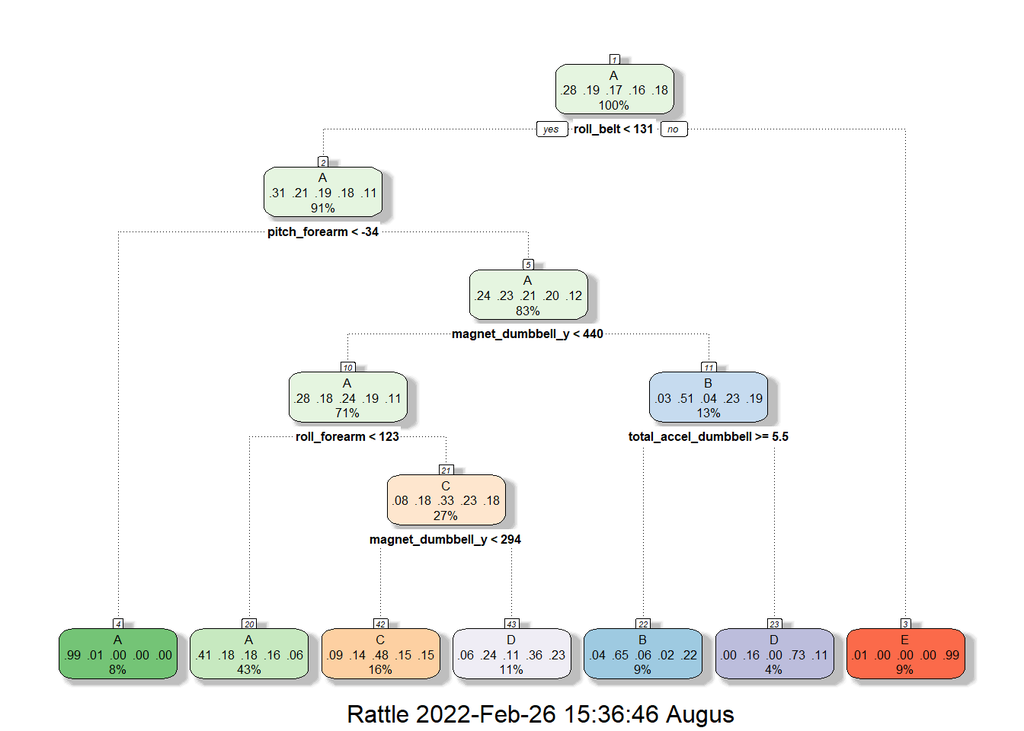

```r
fitTree <- train(classe ~ ., data = training, method = "rpart",
                 trControl = control, tuneLength = 5)
fancyRpartPlot(fitTree$finalModel)
```

#### Confusion matrix:

```r
predTree <- predict(fitTree, testing)
cfTree <- confusionMatrix(predTree, testing$classe)
cfTree
```

```
## Confusion Matrix and Statistics
##
##           Reference
## Prediction    A    B    C    D    E
##          A 1519  476  494  459  174
##          B   25  352   32    9  130
##          C   94  122  423  142  131
##          D   33  189   77  354  173
##          E    3    0    0    0  474
##
## Overall Statistics
##
##                Accuracy : 0.5305
##                  95% CI : (0.5177, 0.5433)
##     No Information Rate : 0.2845
##     P-Value [Acc > NIR] : < 2.2e-16
##
##                   Kappa : 0.3872
##
##  Mcnemar's Test P-Value : < 2.2e-16
##
## Statistics by Class:
##
##                      Class: A Class: B Class: C Class: D Class: E
## Sensitivity            0.9074  0.30904  0.41228  0.36722  0.43808
## Specificity            0.6193  0.95870  0.89936  0.90408  0.99938
## Pos Pred Value         0.4865  0.64234  0.46382  0.42857  0.99371
## Neg Pred Value         0.9439  0.85254  0.87875  0.87942  0.88757
## Prevalence             0.2845  0.19354  0.17434  0.16381  0.18386
## Detection Rate         0.2581  0.05981  0.07188  0.06015  0.08054
## Detection Prevalence   0.5305  0.09312  0.15497  0.14036  0.08105
## Balanced Accuracy      0.7634  0.63387  0.65582  0.63565  0.71873
```

### Random forest

#### Model

```r
fitRF <- train(classe ~ ., data = training, method = "ranger",
                 trControl = control, tuneLength = 5)
fitRF$finalModel
```

```
## Ranger result
##
## Call:
##  ranger::ranger(dependent.variable.name = ".outcome", data = x,      mtry = min(param$mtry, ncol(x)), min.node.size = param$min.node.size,      splitrule = as.character(param$splitrule), write.forest = TRUE,      probability = classProbs, ...)
##
## Type:                             Classification
## Number of trees:                  500
## Sample size:                      13737
## Number of independent variables:  52
## Mtry:                             52
## Target node size:                 1
## Variable importance mode:         none
## Splitrule:                        extratrees
## Number of random splits:          1
## OOB prediction error:             0.45 %
```

#### Confusion matrix

```r
predRF <- predict(fitRF, testing)
cfRF <- confusionMatrix(predRF, testing$classe)
cfRF
```

```
## Confusion Matrix and Statistics
##
##           Reference
## Prediction    A    B    C    D    E
##          A 1674    2    0    0    0
##          B    0 1133    8    0    0
##          C    0    4 1018    8    3
##          D    0    0    0  954    1
##          E    0    0    0    2 1078
##
## Overall Statistics
##
##                Accuracy : 0.9952
##                  95% CI : (0.9931, 0.9968)
##     No Information Rate : 0.2845
##     P-Value [Acc > NIR] : < 2.2e-16
##
##                   Kappa : 0.994
##
##  Mcnemar's Test P-Value : NA
##
## Statistics by Class:
##
##                      Class: A Class: B Class: C Class: D Class: E
## Sensitivity            1.0000   0.9947   0.9922   0.9896   0.9963
## Specificity            0.9995   0.9983   0.9969   0.9998   0.9996
## Pos Pred Value         0.9988   0.9930   0.9855   0.9990   0.9981
## Neg Pred Value         1.0000   0.9987   0.9984   0.9980   0.9992
## Prevalence             0.2845   0.1935   0.1743   0.1638   0.1839
## Detection Rate         0.2845   0.1925   0.1730   0.1621   0.1832
## Detection Prevalence   0.2848   0.1939   0.1755   0.1623   0.1835
## Balanced Accuracy      0.9998   0.9965   0.9946   0.9947   0.9979
```

### Gradient boosting machines

#### Model

```r
fitGBM <- train(classe ~ ., data = training, method = "gbm",
                trControl = control, tuneLength = 5)
fitGBM$finalModel
```

```
## A gradient boosted model with multinomial loss function.
## 250 iterations were performed.
## There were 52 predictors of which 52 had non-zero influence.
```

#### Confusion matrix

```r
predGBM <- predict(fitGBM, testing)
cfGBM <- confusionMatrix(predGBM, testing$classe)
cfGBM
```

```
## Confusion Matrix and Statistics
##
##           Reference
## Prediction    A    B    C    D    E
##          A 1670    5    0    0    0
##          B    4 1127   11    0    4
##          C    0    7 1011    8    5
##          D    0    0    4  955    2
##          E    0    0    0    1 1071
##
## Overall Statistics
##
##                Accuracy : 0.9913
##                  95% CI : (0.9886, 0.9935)
##     No Information Rate : 0.2845
##     P-Value [Acc > NIR] : < 2.2e-16
##
##                   Kappa : 0.989
##
##  Mcnemar's Test P-Value : NA
##
## Statistics by Class:
##
##                      Class: A Class: B Class: C Class: D Class: E
## Sensitivity            0.9976   0.9895   0.9854   0.9907   0.9898
## Specificity            0.9988   0.9960   0.9959   0.9988   0.9998
## Pos Pred Value         0.9970   0.9834   0.9806   0.9938   0.9991
## Neg Pred Value         0.9990   0.9975   0.9969   0.9982   0.9977
## Prevalence             0.2845   0.1935   0.1743   0.1638   0.1839
## Detection Rate         0.2838   0.1915   0.1718   0.1623   0.1820
## Detection Prevalence   0.2846   0.1947   0.1752   0.1633   0.1822
## Balanced Accuracy      0.9982   0.9927   0.9906   0.9947   0.9948
```

## Results

```r
cat(paste0("out-of-sample error for each model (in %)",
           "\nDecision trees: ", round((1 - cfTree$overall["Accuracy"]) * 100, 2),
           "\nRandom forest accuracy: ", round((1 - cfRF$overall["Accuracy"]) * 100, 2),
           "\nGradient boosting accuracy: ", round((1 - cfGBM$overall["Accuracy"]) * 100, 2)))
```

```
## out-of-sample error for each model (in %)
## Decision trees: 46.95
## Random forest accuracy: 0.48
## Gradient boosting accuracy: 0.87
```

## Predictions on validation set

Using the model fit with the least out-of-sample error, we predicted the validation set and obtained the following results:

```r
predict(fitRF, validation)
```

```
##  [1] B A B A A E D B A A B C B A E E A B B B
## Levels: A B C D E
```